# Ejemplo con report

R-Ladies Cuernavaca

Carlos A. Torres Cubilla

## Paquetes utilizados

Para este ejemplo utilizaremos los paquetes `report`, `palmerpenguins`, `dplyr` y `ggpubr`.

## Datos utilizados

The data contains 344 observations, grouped by species, of the following 4 variables:

- Adelie (n = 152):
  - island: 3 levels, namely Biscoe (n = 44), Dream (n = 56) and Torgersen (n = 52)
  - sex: 2 levels, namely female (n = 73), male (n = 73) and missing (n = 6)
  - year: 3 levels, namely 2007 (n = 50), 2008 (n = 50) and 2009 (n = 52)
- Chinstrap (n = 68):
  - island: 3 levels, namely Biscoe (n = 0), Dream (n = 68) and Torgersen (n = 0)
  - sex: 2 levels, namely female (n = 34) and male (n = 34)
  - year: 3 levels, namely 2007 (n = 26), 2008 (n = 18) and 2009 (n = 24)
- Gentoo (n = 124):
  - island: 3 levels, namely Biscoe (n = 124), Dream (n = 0) and Torgersen (n = 0)
  - sex: 2 levels, namely female (n = 58), male (n = 61) and missing (n = 5)
  - year: 3 levels, namely 2007 (n = 34), 2008 (n = 46) and 2009 (n = 44)

## Test de asosiación

La correlación entre las variables bill_length_mm y bill_depth_mm para las tres especies de pinguinos consideradas es de -0.2351Con un p-valor asociado de 1.12e-05. Existe una relación lineal baja entre las variables.

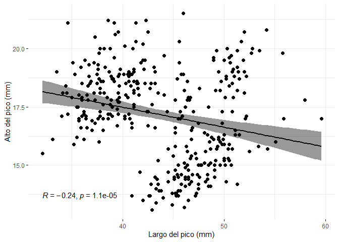

## Diferencia de medias

La diferencia media de body_mass_g en funcion del sex es de 683.4 con un p valor asociado de 4.794e-16. El tamaño de efecto (d de Cohen) asosiado a la diferencia de medias es de -0.95. Existe una diferencia grande entre los grupos considerados.

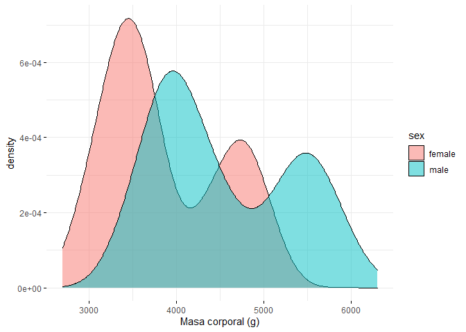

## Regresión lineal

We fitted a linear model to predict body_mass_g with bill_length_mm and bill_depth_mm. The model’s explanatory power is substantial (R2 = 0.47, adj. R2 = 0.47). The model’s intercept is at 3343.14 (95% CI [2497.50, 4188.77]). Within this model:

- The effect of bill_length_mm is statistically significant and positive (beta = 75.28, 95% CI [63.54, 87.03], t(339) = 12.61, p < .001, Std. beta = 0.51)
- The effect of bill_depth_mm is statistically significant and negative (beta = -142.72, 95% CI [-175.19, -110.25], t(339) = -8.65, p < .001, Std. beta = -0.35)

## ANOVA

El efecto species es significativo con un p-valor de 2.892e-82; este efecto representa el 66.97% de la variabilidad total existente. Al menos uno de los grupos de species tiene un una masa corporal distinta.

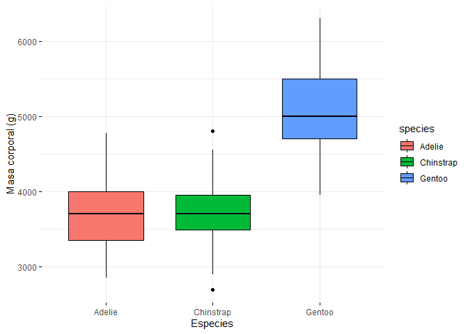